# Data Science Log #1

Rrustem Sallauka

2026-02-24

```r
library(dplyr)
library(tibble)
library(vitae)
knitr::opts_chunk$set(echo = FALSE, warning = FALSE, message = FALSE)
```

Install the `palmerpenguins` package and load the `penguins` dataset into your environment.

```
Compute how many female and male species are available for each
species on each island. What do you notice in the data?
```

| species | island | sex | n |
| --- | --- | --- | --- |
| Adelie | Biscoe | female | 22 |
| Adelie | Biscoe | male | 22 |
| Adelie | Dream | female | 27 |
| Adelie | Dream | male | 28 |
| Adelie | Dream | NA | 1 |
| Adelie | Torgersen | female | 24 |
| Adelie | Torgersen | male | 23 |
| Adelie | Torgersen | NA | 5 |
| Chinstrap | Dream | female | 34 |
| Chinstrap | Dream | male | 34 |

[output cut: 3 more lines]

The species Adelie and Gentoo have missing data in the gender column.

Change the previous code to resolve the issue and save the dataframe.

```
Create an appropriate visualization to display sex, species and
island. Note: You need to transform the data first. Label the axes,
give the graphic a title and make sure that basic visualization
standards are maintained. Interpret what you see in one sentence
```

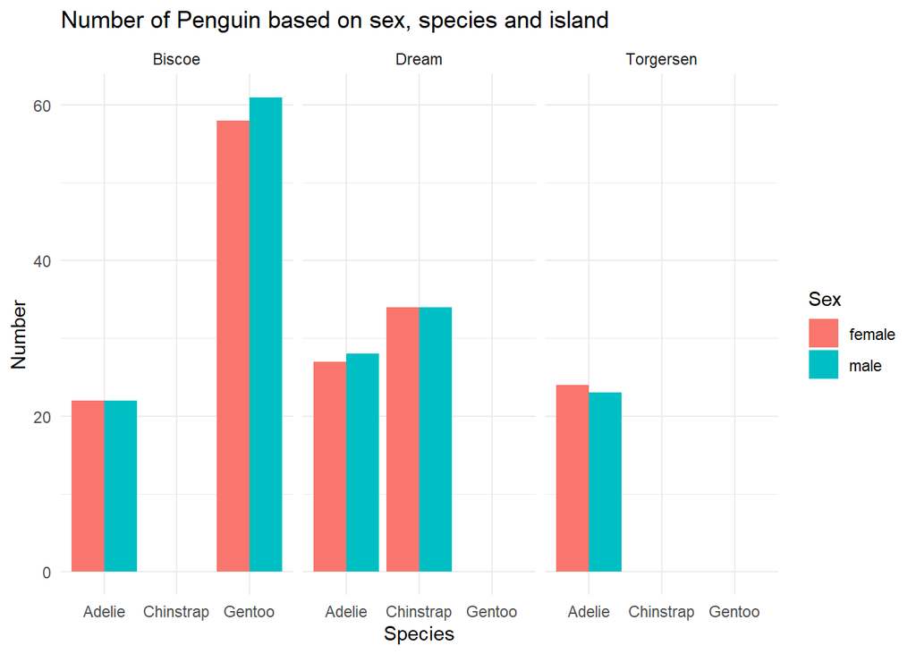

There is no island with all species living on it, while the sex is distributed equally.

## Spotify top chart songs 2022

Download the chart songs dataset from moodle and load it into R. The data is provided by the data science competition platform [Kaggle](https://www.kaggle.com/). You can find a detailed description of all variables in the data on the Kaggle website at https://www.kaggle.com/datasets/sveta151/spotify-top-chart-songs-2022 and a short description below.

```
Create a table displaying the top 15 songs in the dataset, including
the song title, the artists' names, their peak rank and the number
of weeks in the charts. `knitr::kable()`.
```

A table with the top 15 songs

| track_name | artist_names | peak_rank | weeks_on_chart |
| --- | --- | --- | --- |
| Heat Waves | Glass Animals | 1 | 65 |
| STAY (with Justin Bieber) | The Kid LAROI, Justin Bieber | 1 | 37 |
| Envolver | Anitta | 3 | 3 |
| Enemy (with JID) - from the series Arcane League of Legends | Imagine Dragons, JID, Arcane, League of Legends | 3 | 21 |
| abcdefu | GAYLE | 1 | 19 |
| Cold Heart - PNAU Remix | Elton John, Dua Lipa, PNAU | 4 | 32 |
| MAMIII | Becky G, KAROL G | 5 | 6 |
| INDUSTRY BABY (feat. Jack Harlow) | Lil Nas X, Jack Harlow | 2 | 35 |
| Desesperados | Rauw Alejandro, Chencho Corleone | 8 | 15 |
| Shivers | Ed Sheeran | 4 | 28 |
| Woman | Doja Cat | 6 | 37 |
| Easy On Me | Adele | 1 | 23 |
| Ghost | Justin Bieber | 11 | 27 |
| Bam Bam (feat. Ed Sheeran) | Camila Cabello, Ed Sheeran | 13 | 3 |
| MIDDLE OF THE NIGHT | Elley Duhé | 14 | 13 |

Add a caption to your table. Who wrote the second most popular song?

```
Calculate the percentage of songs written in major modality. Hint:
Check out the Kaggle website for details about the variables of the
dataset.
```

```
## [1] 0.5773994
```

```
Create a scatterplot, showing the danceability score of a song on
the X-axis and the energy score on the Y-axis.
```

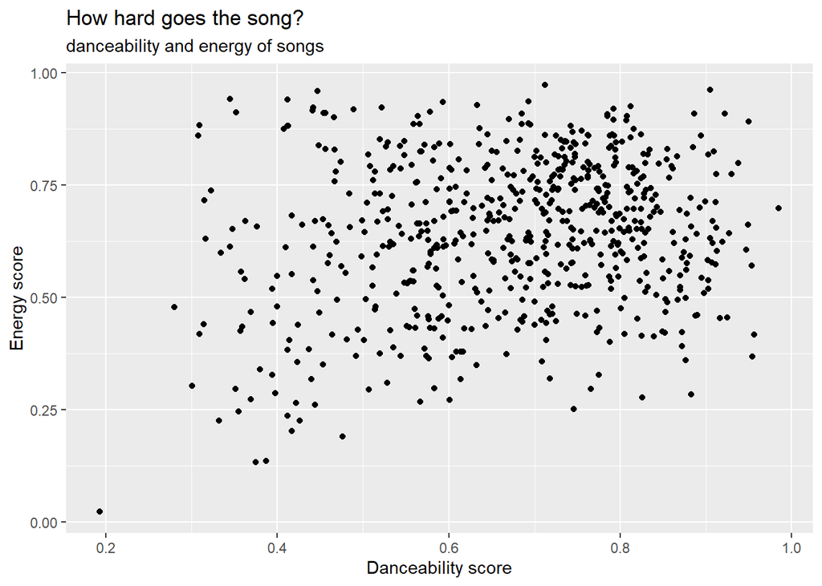

Danceability and Energy of songs

```
Add an appropriate caption to your figure (as part of the Rmarkdown,
not within ggplot).

Write a short sentence describing and interpreting the figure.
Properly
[reference](https://bookdown.org/yihui/rmarkdown-cookbook/cross-ref.html)
the figure in your sentence.
```

```
Write another sentence describing that the figure was generated
using `ggplot2` and add a
[citation](https://bookdown.org/yihui/rmarkdown-cookbook/bibliography.html)
for `ggplot2`.
```

To create this code we used ggplot2 (Wickham 2016)

```
Calculate the correlation between the danceability and the energy
perception. Write a sentence in Markdown and automatically insert
the correct number.
```

The correlation between danceability and the energy is 0.1986587

## Spotify top chart songs 2

```
The number of weeks in charts and peak rank alone cannot fully
reflect a song's popularity: compare a song which was a one hit (aka
one week) wonder with possibly peak rank 1 and a song ranking 10th
place but for multiple weeks. Create a new combined
`popularity_score` metric for songs which is calculated by dividing
the number of weeks the song has been in the charts by its peak
rank.
```

e.g.: Drake:Falling Back(peak rank: 10,weeks in chart: 1) and Imagine Dragons:Believer(peak rank: 16,weeks in chart: 268)

```
Output a formatted table with the **top 15** songs ordered by this
popularity score. Include the song title, the artists' names, the
weeks on chart, the peak rank and the popularity score.
```

- Add a caption to the table.
- Display the popularity score rounded to 3 digits, without rounding by hand.

> Tip: Check out the options in `knitr::kable()`

A table with the top 15 songs

| track_name | artist_names | weeks_on_chart | peak_rank | popularity_score |
| --- | --- | --- | --- | --- |
| Shape of You | Ed Sheeran | 269 | 1 | 269.0 |
| Sunflower - Spider-Man: Into the Spider-Verse | Post Malone, Swae Lee | 179 | 1 | 179.0 |
| Dance Monkey | Tones And I | 140 | 1 | 140.0 |
| Señorita | Shawn Mendes, Camila Cabello | 138 | 1 | 138.0 |
| Circles | Post Malone | 134 | 1 | 134.0 |
| Blinding Lights | The Weeknd | 121 | 1 | 121.0 |
| Starboy | The Weeknd, Daft Punk | 97 | 1 | 97.0 |
| HUMBLE. | Kendrick Lamar | 96 | 1 | 96.0 |
| Closer | The Chainsmokers, Halsey | 179 | 2 | 89.5 |
| Something Just Like This | The Chainsmokers, Coldplay | 172 | 2 | 86.0 |
| Mood (feat. iann dior) | 24kGoldn, iann dior | 85 | 1 | 85.0 |
| positions | Ariana Grande | 74 | 1 | 74.0 |
| DÁKITI | Bad Bunny, Jhay Cortez | 73 | 1 | 73.0 |
| Perfect | Ed Sheeran | 262 | 4 | 65.5 |
| Heat Waves | Glass Animals | 65 | 1 | 65.0 |

```
Write one or two sentences describing the table, focusing on a
comparison of its last two entries in particular. Include a link to
the two songs and properly
[reference](https://bookdown.org/yihui/rmarkdown-cookbook/cross-ref.html)
the table.
```

> Note: Proper referencing of the table will only work when rendering to a PDF. Don’t get hung up on this if it provides some problems, as dealing with LaTeX can be a bit tricky.

```
Add a level-1 heading called `Supplementary Materials` and put the
following figure under it.
```

# Supplementary Materials

```
Create a histogram illustrating the danceability of the songs,
coloured by modality.
```

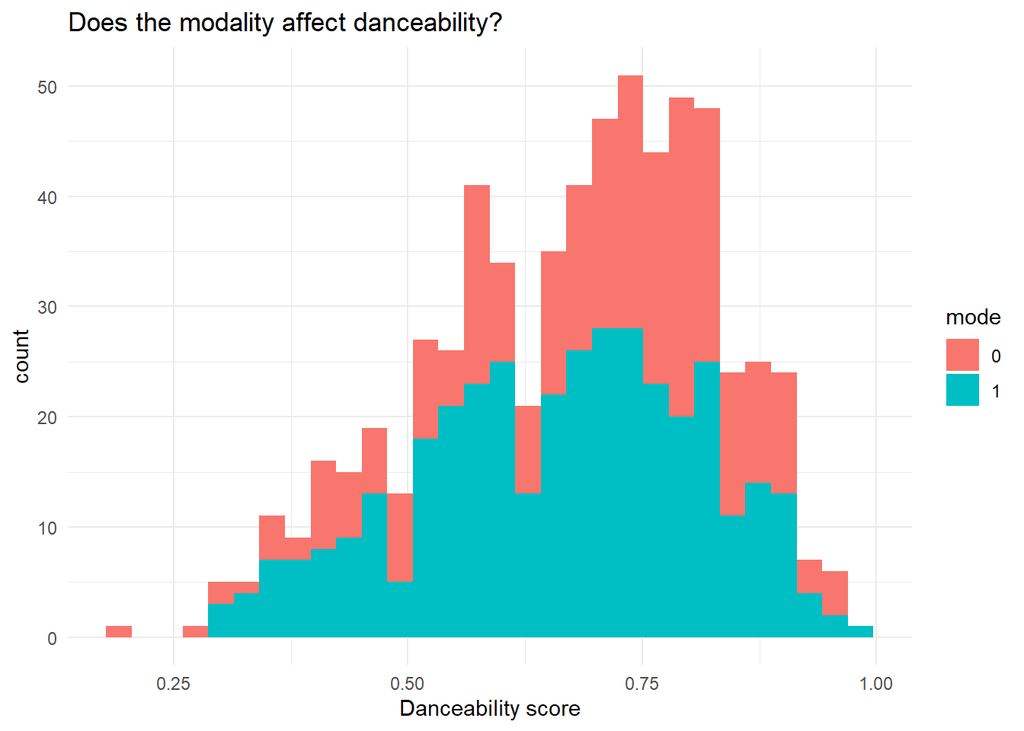

```
What do you notice in the histogram? Are there general trends across
modalities or clear differences?
```

There is no clear trend visible, which suggests the independence of modality and danceability.

```
Include a the full [list of
citations](https://bookdown.org/yihui/rmarkdown-cookbook/bibliography.html#include-appendix-after-bibliography)
under a level-1 heading "References" including the details of your
citation. Insert this list of references before the heading
`Supplementary Materials`.
```

# References

Wickham (2016)

Wickham, Hadley. 2016. *Ggplot2: Elegant Graphics for Data Analysis*. Springer-Verlag New York. https://ggplot2.tidyverse.org.